# Analiza comparativă România vs UE privind indicatorii climatici

## Obiectiv

Scopul acestei analize este de a compara poziția României față de media Uniunii Europene din perspectiva unor indicatori relevanți pentru tranziția climatică.

Analiza vizează trei dimensiuni principale:

- **Emisii de gaze cu efect de seră** — evoluția istorică și țintele asumate față de media UE
- **Energie regenerabilă** — ponderea surselor verzi în mixul energetic național comparativ cu standardele europene
- **Eficiență energetică** — intensitatea energetică a economiei și progresul față de obiectivele Green Deal

Prin această comparație, se urmărește identificarea decalajelor existente, a progreselor înregistrate și a domeniilor prioritare în care România necesită accelerarea politicilor climatice pentru alinierea la angajamentele europene asumate pentru 2030 și 2050.

## Context general: Inițiative climatice în Uniunea Europeană

Uniunea Europeană se poziționează ca unul dintre liderii globali în domeniul politicilor climatice, prin implementarea unor strategii integrate menite să reducă impactul asupra mediului și să accelereze tranziția către o economie sustenabilă.

Aceste inițiative urmăresc realizarea unei tranziții ecologice care să fie nu doar eficientă din punct de vedere economic, ci și echitabilă din punct de vedere social, protejând atât mediul, cât și cetățenii.

Sursa: climate.ec.europa.eu

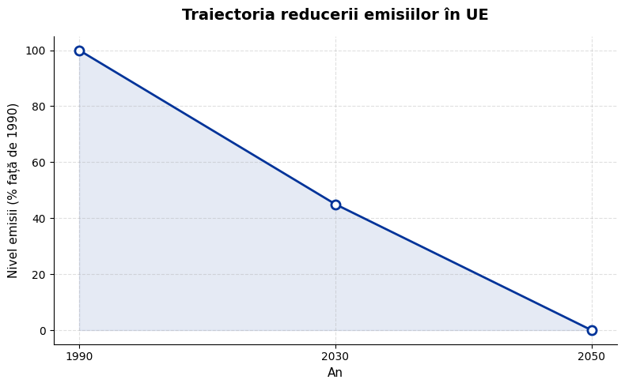

Graficul ilustrează traiectoria planificată de reducere a emisiilor de gaze cu efect de seră la nivelul Uniunii Europene. Se observă un obiectiv ambițios de reducere semnificativă până în anul 2030, urmat de atingerea neutralității climatice până în 2050. Această evoluție reflectă angajamentul UE de a deveni lider global în combaterea schimbărilor climatice.

Germania este una dintre țările europene care au un rol central în promovarea și finanțarea inițiativelor climatice. Un exemplu relevant este International Climate Initiative (IKI), inițiativă susținută de guvernul german, care finanțează proiecte privind clima, biodiversitatea și tranziția verde. În paralel, profilul de țară publicat de European Environment Agency arată că Germania înregistrează progrese importante în anumite domenii, dar și decalaje în altele, ceea ce o face un exemplu de lider climatic „complex”: avansat instituțional, dar încă în proces de transformare structurală.

## Țările lider ca inițiative climatice

conform -> CCPI — Climate Change Performance Index

## Norvegia — Profil climatic

Norvegia este lider global în tranziția energetică, cu aproape toată electricitatea produsă din surse regenerabile (preponderent hidropower).

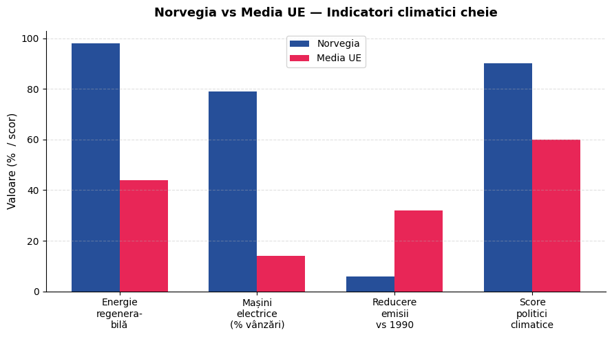

Modelul norvegian este însă greu de replicat direct, fiind dependent de geografia specifică (resurse hidroelectrice abundente) și de veniturile din fondul petrolier național.

**Surse** https://www.iea.org/countries/norway https://ec.europa.eu/eurostat/statistics-explained/index.php/Renewable_energy_statistics https://ec.europa.eu/eurostat/statistics-explained/index.php/Greenhouse_gas_emission_statistics

### Suedia — lider legislativ în politici climatice

Suedia este una dintre primele țări care au implementat politici climatice bazate pe instrumente economice și legislative coerente.

Un element central îl reprezintă introducerea taxei pe carbon în 1991, una dintre primele de acest tip la nivel global. În prezent, Suedia aplică una dintre cele mai ridicate taxe pe carbon, contribuind semnificativ la reducerea emisiilor de CO₂.

În 2017, Suedia a adoptat un cadru legislativ climatic care stabilește obiective pe termen lung, inclusiv atingerea neutralității climatice până în 2045. Acest cadru este susținut de instituții independente care monitorizează implementarea politicilor.

Eficiența acestor măsuri este reflectată în reducerea emisiilor per capita și a intensității carbonice a economiei, ambele situându-se sub media Uniunii Europene. De asemenea, sistemele de taxare a carbonului și EU ETS acoperă majoritatea emisiilor provenite din combustibili fosili.

Aceste elemente poziționează Suedia ca un exemplu de bună practică în domeniul politicilor climatice la nivel european.

**Surse:**

- https://www.government.se/government-policy/taxes-and-tariffs/swedens-carbon-tax/
- https://www.government.se/articles/2021/03/swedens-climate-policy-framework/
- https://www.europarl.europa.eu/thinktank/en/document/EPRS_BRI(2024)767174

### Danemarca — lider în guvernanță climatică

Danemarca se remarcă printr-un model avansat de guvernanță climatică, bazat pe legislație strictă și mecanisme instituționale solide.

Legea climatică adoptată în 2020 stabilește obiective obligatorii de reducere a emisiilor până în 2030 și introduce un mecanism de revizuire periodică a politicilor climatice, evaluat de un consiliu independent de experți.

Un element inovator îl reprezintă introducerea unei taxe pe emisiile de CO₂ în sectorul agricol, considerată o premieră la nivel global. Aceasta extinde politicile climatice către un sector dificil de reglementat.

Reforma fiscală verde din 2022 a accelerat tranziția industrială, prin stimularea investițiilor în tehnologii curate și reducerea emisiilor.

La nivel internațional, Danemarca participă la proiecte de captare și stocare a carbonului (CCS), în colaborare cu alte state europene, contribuind la dezvoltarea soluțiilor tehnologice pentru reducerea emisiilor.

Prin aceste măsuri, Danemarca este considerată un model de implementare eficientă a politicilor climatice în Uniunea Europeană.

**Surse:**

- https://www.europarl.europa.eu/thinktank/en/document/EPRS_BRI(2024)767174
- https://www.tandfonline.com/doi/full/10.1080/07036337.2025.2459298

## Țările lider după Environmental Performance Index (EPI)

Indicele de Performanță de Mediu (EPI) analizează mai mulți factori pentru a determina cât de aproape sunt țările de atingerea obiectivelor internaționale de politici de mediu și cum se compară acestea cu alte națiuni. Factorii de decizie pot utiliza EPI pentru a lua decizii care să orienteze agendele de mediu ale țărilor lor către obiective internaționale comune. Primele trei țări clasate sunt Estonia, Luxembourg și Germany, ceea ce confirmă poziția puternică a unor state europene în domeniul politicilor de mediu și al tranziției verzi.

## Bune practici și lecții învățate în inițiativele europene de tip climate-neutral / smart cities

La nivel european, experiența programelor pentru orașe inteligente și neutre climatic arată că succesul nu depinde doar de tehnologie, ci mai ales de guvernanță, finanțare, coordonare interinstituțională și participare civică. Auditul Curții de Conturi Europene asupra programului Lighthouse a concluzionat că proiectele au produs soluții concrete, dar adoptarea lor pe scară largă a fost limitată de fragmentare, de lipsa clarității privind finanțarea și de dificultatea replicării între orașe. În paralel, Misiunea UE pentru 100 de orașe climatice a fost construită tocmai pentru a depăși aceste limite prin abordări integrate și prin Climate City Contracts. Misiunea a selectat 112 orașe din 377 candidate, iar până în mai 2025, 92 dintre ele primiseră deja Mission Label, ceea ce arată un progres instituțional important, dar nu elimină blocajele structurale.

**surse**

- https://research-and-innovation.ec.europa.eu/funding/funding-opportunities/funding-programmes-and-open-calls/horizon-europe/eu-missions-horizon-europe/climate-neutral-and-smart-cities_en?utm_source=chatgpt.com
- https://www.eca.europa.eu/ECAPublications/SR-2023-24/SR-2023-24_EN.pdf

## Bune practici identificate în orașele europene

O primă bună practică este abordarea integrată. Documentele Comisiei Europene arată că neutralitatea climatică nu poate fi atinsă prin măsuri sectoriale separate, ci printr-o strategie holistică care combină mobilitatea, energia, clădirile și implicarea cetățenilor. Climate City Contracts sunt relevante deoarece reunesc într-un singur cadru angajamentele politice, planul de acțiune și planul de investiții.

A doua bună practică este guvernanța colaborativă. Exemplele promovate de NetZeroCities includ orașe precum Oslo și Leuven, unde administrația colaborează cu sectorul privat, universități și comunități locale. În cazul Leuven, contractul climatic implică peste 25 de actori locali, ceea ce facilitează implementarea.

A treia bună practică este pregătirea financiară. Orașele performante sunt cele care reușesc să transforme proiectele în investiții „bankable”, atrăgând atât fonduri publice, cât și private. Aceasta presupune expertiză financiară și o planificare riguroasă.

A patra bună practică este implicarea cetățenilor. Curtea de Conturi Europeană arată că aproximativ 75% dintre proiecte au întâmpinat dificultăți din cauza participării insuficiente a populației.

Aceste bune practici evidențiază faptul că succesul nu este determinat de tehnologie, ci de modul în care aceasta este integrată în sistemul urban și acceptată social.

Se poate afirma că orașele care tratează tranziția climatică ca un proces colectiv și interdisciplinar au șanse semnificativ mai mari de reușită.

## Lecții învățate și greșeli care trebuie evitate

Una dintre cele mai importante greșeli este tehnologizarea fără guvernanță. Conform OECD (2023), multe proiecte smart city au probleme de scalabilitate și sustenabilitate deoarece nu sunt clar definite responsabilitățile instituționale și regulile privind utilizarea datelor.

Un exemplu relevant este proiectul Sidewalk Toronto, abandonat în 2020. Inițiativa, dezvoltată de Sidewalk Labs (parte a Alphabet), urmărea transformarea unei zone urbane din Toronto într-un model global de smart city, bazat pe utilizarea extensivă a datelor, senzorilor și inteligenței artificiale. Cu toate acestea, proiectul a generat controverse majore legate de guvernanța datelor, lipsa clarității privind cine controlează informațiile colectate și modul în care acestea sunt utilizate. De asemenea, au existat preocupări privind supravegherea excesivă și lipsa unui control democratic clar. În final, opoziția publică, combinată cu incertitudinile economice și instituționale, a condus la abandonarea proiectului. Acest caz demonstrează că, în absența legitimității sociale și a unui cadru de guvernanță transparent, chiar și cele mai avansate inițiative tehnologice pot eșua.

O altă greșeală este pilotarea fără replicare. Auditul Curții de Conturi Europene arată că multe proiecte din programul Lighthouse au produs rezultate pozitive la scară locală, însă nu au fost scalate eficient sau replicate în alte orașe. Lipsa standardizării, a unor modele financiare sustenabile și a coordonării între niveluri de guvernare limitează impactul acestor inițiative.

În plus, subestimarea birocrației și a capacității administrative reprezintă un obstacol major. Majoritatea barierelor identificate sunt instituționale, nu tehnice.În multe cazuri, problema nu este lipsa finanțării, ci incapacitatea de a gestiona și implementa eficient proiectele existente.

Aceste exemple demonstrează că eșecul nu apare din lipsa tehnologiei, ci din lipsa unei structuri clare de implementare și acceptare socială.

Rezultă că orice strategie de smart city trebuie să prioritizeze guvernanța, transparența și implicarea cetățenilor înaintea implementării tehnologice.

**Surse**

- https://www.oecd.org/content/dam/oecd/en/publications/reports/2023/10/smart-city-data-governance_fc19e878/e57ce301-en.pdf
- https://www.waterfrontoronto.ca/news/statement-waterfront-toronto-board-chair-stephen-diamond-0
- https://www.eca.europa.eu/ECAPublications/SR-2023-24/SR-2023-24_EN.pdf

### Poziția României în context european

România se situează într-o poziție intermediară în cadrul tranziției verzi europene, caracterizată prin performanțe relativ bune la nivelul unor indicatori cantitativi, dar cu decalaje semnificative în ceea ce privește eficiența sistemică și implementarea politicilor de mediu.

La nivel european, inițiativele de tip „climate-neutral cities” și strategiile de economie circulară sunt susținute de state lider precum Germania, Olanda sau Suedia, care combină investițiile în infrastructură verde cu sisteme eficiente de guvernanță și monitorizare a datelor. În acest context, România participă limitat la inițiativele europene de vârf, având doar trei entități selectate în cadrul EU Mission Cities, ceea ce indică un nivel redus de integrare în nucleul inovator al politicilor urbane climatice.

Din perspectiva indicatorilor de mediu, România prezintă un profil contrastant: pe de o parte, nivelul emisiilor de gaze cu efect de seră per capita și cantitatea de deșeuri generate sunt sub media Uniunii Europene; pe de altă parte, eficiența utilizării resurselor, ratele de reciclare și intensitatea emisiilor raportată la PIB rămân semnificativ sub standardele europene.

Această combinație sugerează că performanța aparent favorabilă este determinată mai degrabă de un nivel mai scăzut al consumului și dezvoltării economice, decât de eficiența politicilor de mediu, ceea ce evidențiază necesitatea unor investiții structurale și a unei guvernanțe mai coerente în domeniul sustenabilității.

**source**

- https://netzerocities.eu/mission-cities/

|  | TIME | 2015 | Unnamed: 2 | 2016 | Unnamed: 4 | 2017 | Unnamed: 6 | 2018 | Unnamed: 8 | 2019 | ... | 2020 | Unnamed: 12 | 2021 | Unnamed: 14 | 2022 | Unnamed: 16 | 2023 | Unnamed: 18 | 2024 | Unnamed: 20 |
| --- | --- | --- | --- | --- | --- | --- | --- | --- | --- | --- | --- | --- | --- | --- | --- | --- | --- | --- | --- | --- | --- |
| 0 | CO2 | 65030286.64 | NaN | 63305955.65 | NaN | 65322442.46 | NaN | 65048719.72 | NaN | 61734166.51 | ... | 58150269.69 | NaN | 60073540.54 | NaN | 56086820.14 | NaN | 50283851.20 | NaN | 62664390.52 | i |
| 1 | CH4 | 957522.40 | NaN | 934304.43 | NaN | 916745.19 | NaN | 900419.42 | NaN | 909167.66 | ... | 890655.86 | NaN | 870438.27 | NaN | 861540.95 | NaN | 843859.24 | NaN | 788373.43 | NaN |
| 2 | N2O | 34780.66 | NaN | 34726.44 | NaN | 36311.63 | NaN | 38920.55 | NaN | 37630.53 | ... | 35303.07 | NaN | 38059.98 | NaN | 33751.49 | NaN | 33921.63 | NaN | 29926.14 | NaN |

3 rows × 21 columns

```
Saved to: D:\Downloads\ICI proiect\ICI_Proiect\data\processed\emissions_clean.csv
```

|  | gas | year | value | region | index_2015 |
| --- | --- | --- | --- | --- | --- |
| 1 | CO2 | 2015 | 2.598788e+09 | EU27 | 100.000000 |
| 5 | CO2 | 2016 | 2.594087e+09 | EU27 | 99.819115 |
| 9 | CO2 | 2017 | 2.644091e+09 | EU27 | 101.743254 |
| 13 | CO2 | 2018 | 2.572979e+09 | EU27 | 99.006880 |
| 17 | CO2 | 2019 | 2.442155e+09 | EU27 | 93.972853 |
| 21 | CO2 | 2020 | 2.147113e+09 | EU27 | 82.619803 |
| 25 | CO2 | 2021 | 2.313315e+09 | EU27 | 89.015159 |
| 29 | CO2 | 2022 | 2.303143e+09 | EU27 | 88.623745 |
| 33 | CO2 | 2023 | 2.085707e+09 | EU27 | 80.256934 |
| 37 | CO2 | 2024 | 2.050885e+09 | EU27 | 78.917001 |
| 0 | CO2 | 2015 | 6.503029e+07 | Romania | 100.000000 |
| 3 | CO2 | 2016 | 6.330596e+07 | Romania | 97.348419 |
| 6 | CO2 | 2017 | 6.532244e+07 | Romania | 100.449261 |
| 9 | CO2 | 2018 | 6.504872e+07 | Romania | 100.028345 |
| 12 | CO2 | 2019 | 6.173417e+07 | Romania | 94.931408 |
| 15 | CO2 | 2020 | 5.815027e+07 | Romania | 89.420288 |
| 18 | CO2 | 2021 | 6.007354e+07 | Romania | 92.377788 |
| 21 | CO2 | 2022 | 5.608682e+07 | Romania | 86.247229 |
| 24 | CO2 | 2023 | 5.028385e+07 | Romania | 77.323742 |
| 27 | CO2 | 2024 | 6.266439e+07 | Romania | 96.361855 |

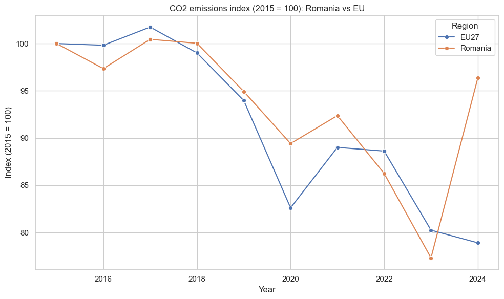

Pentru a compara corect România cu UE, emisiile au fost transformate într-un index cu baza 2015 = 100. Aceasta înseamnă că toate valorile sunt raportate la nivelul din 2015: o valoare de 90 indică o reducere de 10%, iar o valoare de 110 indică o creștere de 10% față de anul de referință.

## Interpretare: Emisii CO₂ — România vs UE27 (2015–2023)

> **Notă metodologică:** Graficul prezintă un **indice relativ (2015 = 100)**, nu valori absolute. Aceasta înseamnă că ambele serii pornesc din același punct și reflectă **ritmul de schimbare** față de anul de referință, nu scala emisiilor în tone. UE27 emite în total de ~40x mai mult decât România — graficul nu arată acest lucru.

### Ce observăm:

**2. România — traiectorie mai volatilă** România oscilează mai mult între ani, sugerând că reducerile de emisii sunt mai degrabă **conjuncturale** (criză energetică, scădere industrială) decât rezultatul unor politici climatice structurale.

**3. 2020 — efectul COVID vizibil la ambele** Scăderea bruscă din 2020 este comună ambelor serii și reflectă oprirea activității industriale și reducerea transportului în perioada pandemiei.

**4. 2021 — revenire post-pandemică** Ambele înregistrează o ușoară creștere în 2021, odată cu reluarea activității economice.

**5. 2022–2023 — România scade mai rapid decât UE** România ajunge sub media UE ca ritm de scădere — parțial explicat prin reducerea producției industriale și închiderea unor capacități pe cărbune.

### Concluzie

Deși România pare să reducă emisiile în ritm similar cu UE, **natura acestor reduceri diferă fundamental**: UE investește activ în tranziție verde, în timp ce România beneficiază mai mult de factori externi (criză energetică, dezindustrializare). Fără politici climatice ambițioase, România riscă să rămână în urmă față de țintele europene pentru **2030**.

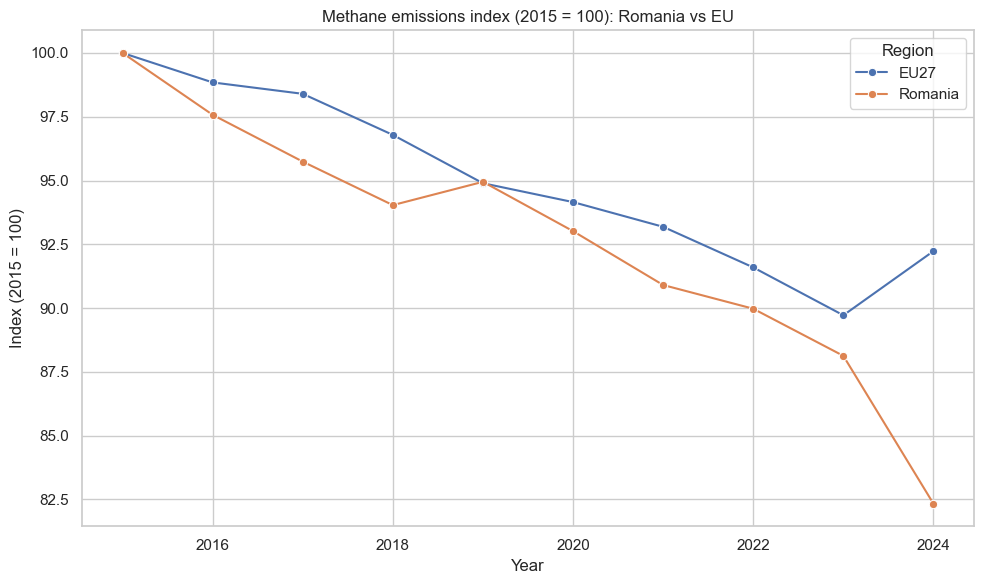

Interpretare:

Reprezentarea emisiilor de metan (CH4) sub formă de index (2015 = 100) permite compararea directă a dinamicii reducerii emisiilor între România și Uniunea Europeană, eliminând diferențele de scară absolută.

În anul de referință 2015, emisiile de metan au fost de aproximativ 957 mii tone în România și 14,7 milioane tone la nivelul UE, aceste valori fiind transformate în indexul 100.

În intervalul 2020–2023, tendința descendentă continuă, însă România menține un nivel constant mai redus decât UE. În 2023, emisiile României ajung la aproximativ 843 mii tone (index ~88), comparativ cu UE, care înregistrează aproximativ 13,2 milioane tone (index ~90).

În 2024, se observă o divergență semnificativă: România continuă scăderea până la aproximativ 788 mii tone (index ~82), în timp ce UE înregistrează o ușoară creștere la aproximativ 13,5 milioane tone (index ~92).

|  | gas |
| --- | --- |
| 0 | GEO (Labels) |
| 1 | CO2 |
| 2 | CH4 |
| 3 | N20 |

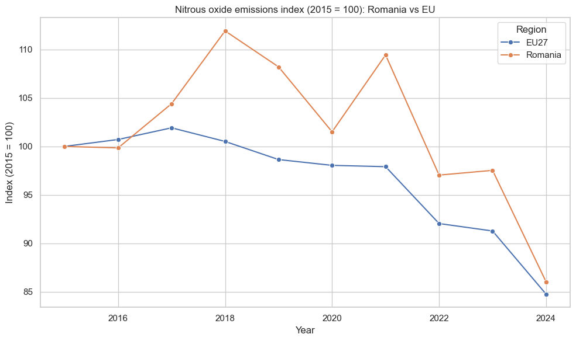

Interpretare:

Evoluția emisiilor de oxid de azot (N2O), exprimată ca index (2015 = 100), evidențiază diferențe semnificative între România și Uniunea Europeană în ceea ce privește stabilitatea și ritmul reducerii.

În anul de referință 2015, emisiile de N2O au fost de aproximativ 34,8 mii tone în România și 660 mii tone la nivelul UE.

În perioada 2015–2018, România înregistrează o creștere semnificativă a emisiilor, ajungând la aproximativ 38,9 mii tone în 2018 (index ~112), în timp ce UE menține valori relativ stabile, în jurul a 660–670 mii tone (index ~100–102).

În intervalul 2019–2021, România începe o tendință descendentă, dar cu fluctuații, coborând la aproximativ 37–38 mii tone, urmată de o revenire în 2021. În același timp, UE înregistrează o scădere graduală, ajungând la aproximativ 646 mii tone în 2021 (index ~98).

După 2021, reducerea devine mai pronunțată pentru ambele entități. În 2024, România ajunge la aproximativ 29,9 mii tone (index ~86), iar UE la aproximativ 560 mii tone (index ~85), marcând cele mai scăzute valori din perioada analizată.

Concluzie generală:

Analiza comparativă a emisiilor de CO2, CH4 și N2O între România și Uniunea Europeană evidențiază un profil diferit al performanței de mediu, caracterizat printr-un contrast între ritmul de reducere și stabilitatea acestuia.

În cazul emisiilor de CO2, UE se remarcă printr-o traiectorie descendentă mai stabilă și mai consistentă, în timp ce România prezintă fluctuații semnificative și o revenire recentă, sugerând o implementare mai puțin eficientă a politicilor de decarbonizare.

Pentru metan (CH4), România înregistrează o reducere mai rapidă și mai accentuată decât UE, ceea ce indică progrese importante în anumite sectoare, însă această performanță nu este neapărat însoțită de stabilitate pe termen lung.

În cazul oxidului de azot (N2O), UE demonstrează din nou o evoluție mai controlată și predictibilă, în timp ce România prezintă o volatilitate ridicată, cu perioade de creștere care indică vulnerabilități structurale în gestionarea emisiilor.

Per ansamblu, Uniunea Europeană se caracterizează printr-o abordare mai coerentă și stabilă în reducerea emisiilor, în timp ce România, deși înregistrează progrese în anumite direcții (în special pentru CH4), prezintă o lipsă de consistență și o sensibilitate mai ridicată la factori economici și politici. Această situație sugerează necesitatea consolidării politicilor de mediu și a investițiilor structurale pentru asigurarea unei tranziții sustenabile pe termen lung.

|  | GEO (Labels) | Unnamed: 1 | Unnamed: 2 | Unnamed: 3 | Unnamed: 4 | Unnamed: 5 | Unnamed: 6 | Unnamed: 7 | Unnamed: 8 | Unnamed: 9 | ... | Unnamed: 39 | Unnamed: 40 | Unnamed: 41 | Unnamed: 42 | Unnamed: 43 | Unnamed: 44 | Unnamed: 45 | Unnamed: 46 | Unnamed: 47 | Unnamed: 48 |
| --- | --- | --- | --- | --- | --- | --- | --- | --- | --- | --- | --- | --- | --- | --- | --- | --- | --- | --- | --- | --- | --- |
| 0 | Belgium | 7.12 | NaN | 5.62 | NaN | 6.32 | NaN | 10.47 | NaN | 11.75 | ... | 4.21 | NaN | 3.69 | NaN | 3.13 | NaN | 6.87 | NaN | 3.42 | NaN |
| 1 | Bulgaria | 1.44 | NaN | 1.10 | NaN | 0.99 | NaN | 1.48 | NaN | 1.01 | ... | 0.99 | NaN | 1.03 | NaN | 0.91 | NaN | 1.34 | NaN | 0.85 | NaN |
| 2 | Czechia | 3.09 | NaN | 2.70 | NaN | 1.89 | NaN | 4.24 | NaN | 3.53 | ... | 3.40 | NaN | 2.35 | NaN | 2.34 | NaN | 3.24 | NaN | 2.16 | NaN |
| 3 | Denmark | 3.39 | NaN | 3.98 | NaN | 3.51 | NaN | 4.84 | NaN | 4.10 | ... | 4.34 | NaN | 4.00 | NaN | 4.91 | NaN | 5.21 | NaN | 3.85 | NaN |
| 4 | Germany | 4.32 | NaN | 3.96 | NaN | 3.21 | NaN | 5.10 | NaN | 4.89 | ... | 4.03 | NaN | 4.12 | NaN | 3.81 | NaN | 4.57 | NaN | 3.35 | NaN |

5 rows × 49 columns

|  | country | year | value |
| --- | --- | --- | --- |

[output not shown]

15 rows × 49 columns

```
(648, 3)
    country  year  value
0   Belgium  2000   7.12
1  Bulgaria  2000   1.44
2   Czechia  2000   3.09
3   Denmark  2000   3.39
4   Germany  2000   4.32
<StringArray>
[ 'Belgium', 'Bulgaria',  'Czechia',  'Denmark',  'Germany',  'Estonia',
  'Ireland',   'Greece',    'Spain',   'France']
Length: 10, dtype: str
```

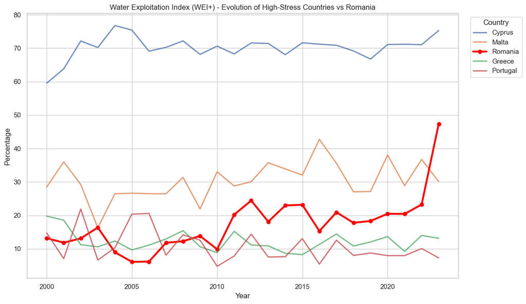

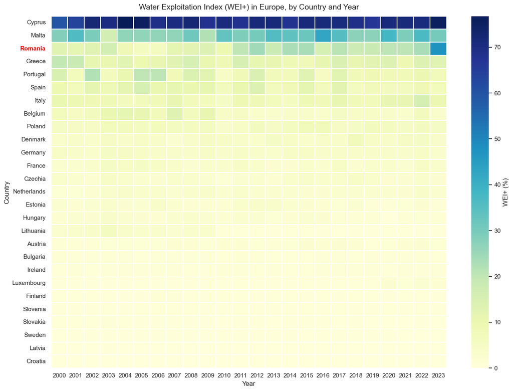

## Analiza comparativă a indicatorului WEI+ în Uniunea Europeană și poziția României

În acest context, România prezintă o evoluție semnificativ diferită, caracterizată printr-o tendință de creștere și o volatilitate mai ridicată. În anul 2000, nivelul WEI+ era de aproximativ 13.17%, iar în perioada 2000–2010 valorile au fluctuat între circa 6% și 16% (de exemplu 6.10% în 2005 și 13.84% în 2009), indicând un nivel moderat de utilizare a resurselor. După 2010, se observă o creștere treptată, cu valori precum 24.42% în 2012 și 23.16% în 2015. În perioada recentă, indicatorul continuă să crească: 20.48% în 2020, 23.26% în 2022, ajungând la 47.38% în 2023, ceea ce reprezintă o creștere abruptă și plasează România în zona statelor cu stres hidric ridicat. Astfel, România depășește state precum Portugalia (7.27% în 2023) și se apropie de niveluri specifice unor țări sudice, deși pornește de la un context diferit. Această evoluție indică o presiune în creștere asupra resurselor de apă și sugerează existența unor vulnerabilități structurale, în contrast cu traiectoriile stabile și reduse ale statelor din vestul și nordul Europei.

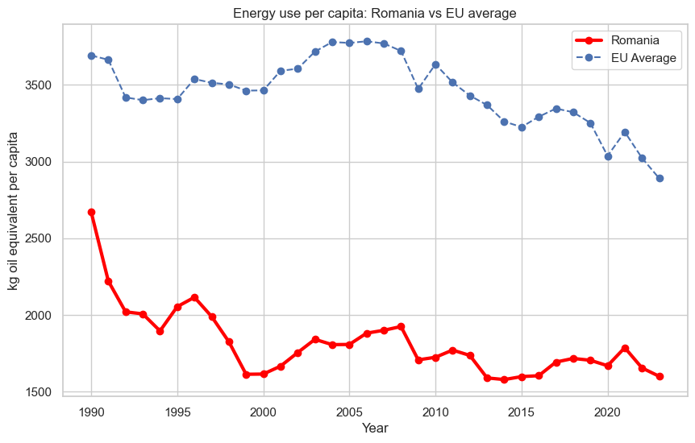

Analiza consumului de energie pe cap de locuitor evidențiază o diferență structurală semnificativă între România și media Uniunii Europene, cu implicații directe asupra amprentei de carbon și a sustenabilității economice.

Graficul evoluției arată că, pe întreaga perioadă analizată, România înregistrează valori constant mai reduse ale consumului de energie (aproximativ 1.600–2.000 kg echivalent petrol/capita), comparativ cu media UE, situată în intervalul 3.000–3.800 kg. Această diferență nu indică neapărat o eficiență energetică superioară, ci reflectă în mare parte un nivel mai scăzut al activității economice și industriale, precum și un consum mai redus la nivel individual.

Din perspectivă ecologică, acest nivel mai scăzut al consumului energetic contribuie la o presiune relativ mai mică asupra mediului și, implicit, la emisii de gaze cu efect de seră mai reduse în termeni absoluți. Totuși, corelat cu analiza emisiilor de CO₂ realizată anterior, rezultă că România nu transformă acest avantaj într-o eficiență reală, deoarece fluctuațiile și lipsa unei traiectorii constante sugerează o dependență de factori conjuncturali, mai degrabă decât de politici energetice eficiente.

Clasamentul pentru anul 2023 consolidează această interpretare: România se situează în partea inferioară a ierarhiei europene, alături de economii cu consum energetic redus, în timp ce state precum Finlanda, Luxemburg sau Suedia înregistrează valori de peste 4.000–5.000 kg echivalent petrol/capita. Aceste diferențe reflectă modele economice distincte, dar și niveluri diferite de electrificare și eficiență tehnologică.

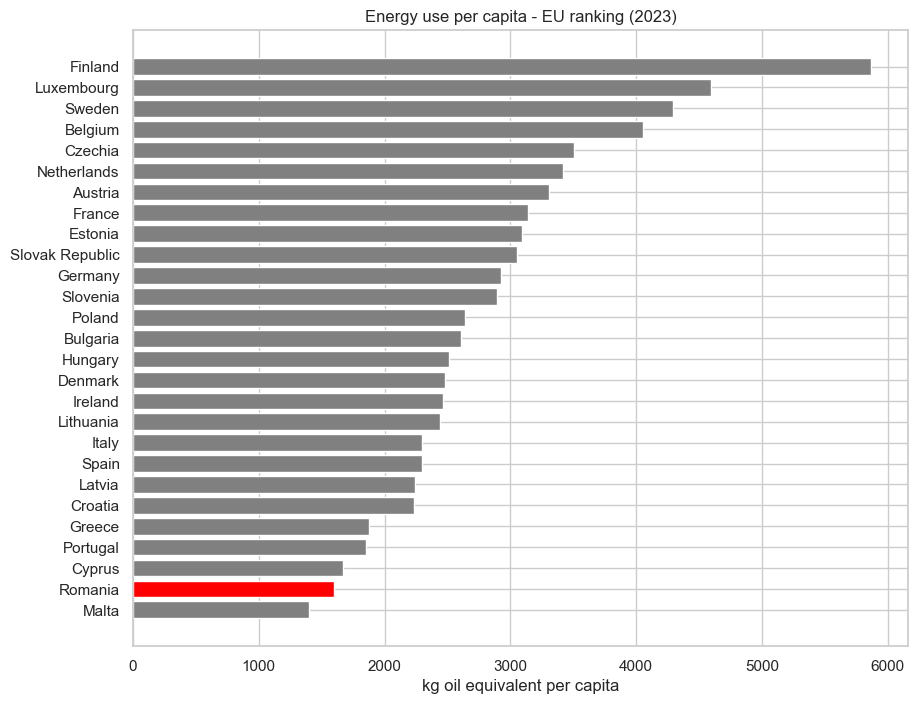

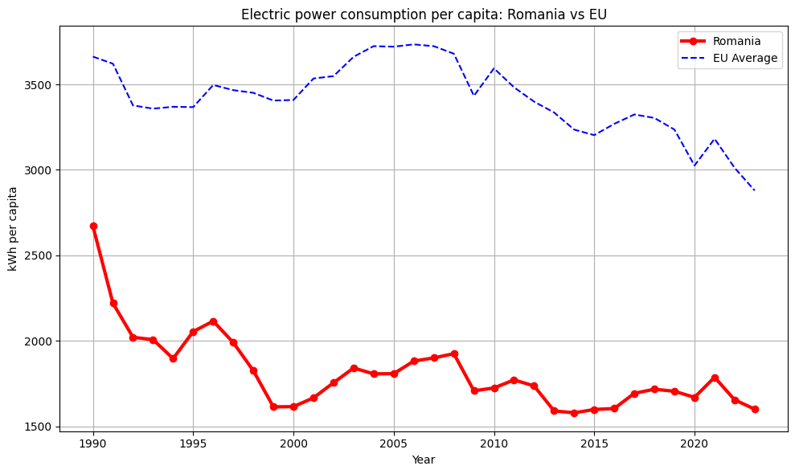

[figure not shown]

Interpretare: Analiză comparativă: România vs media UE (dinamică în timp)

În perioada anilor ’90, România înregistrează o scădere accentuată, ajungând la aproximativ 1600 kWh/capita în jurul anului 2000, ceea ce reflectă tranziția economică și restructurarea industrială. În contrast, media UE rămâne relativ stabilă, oscilând între 3400 și 3600 kWh/capita, ceea ce sugerează o economie matură și stabilă energetic.

În perioada recentă (2015–2023), se observă o tendință de stagnare relativă în România, cu valori în jur de 1600–1800 kWh/capita, în timp ce media UE începe chiar să scadă, ajungând la aproximativ 2900 kWh/capita în 2023. Această convergență aparentă nu reflectă o creștere a României, ci mai degrabă o reducere a consumului în UE, posibil datorită eficienței energetice și tranziției către surse sustenabile.

**Surse** https://data.worldbank.org/

**Sursa** https://data.worldbank.org/indicator/EG.USE.PCAP.KG.OE?end=2025&start=2000

** Contextul European și Misiunea M100 **

Misiunea europeană „100 Green Cities” urmărește transformarea a 100 de orașe europene în lideri ai tranziției ecologice până în 2030. În România, inițiativa similară, cunoscută sub numele de M100, se bazează pe modelul european, adaptându-se la specificul local. Aceasta presupune selectarea a 10 orașe din România, care vor beneficia de resurse și suport pentru a deveni neutre din punct de vedere climatic și inteligente până în 2035. M100 simbolizează angajamentul față de o viziune mai amplă – una care depășește limitele acestor orașe și urmărește să creeze un val de sustenabilitate și inovație la nivelul întregii țări.

Obiectivele lui M100:

- Sprijin pentru orașele selectate: M100 va oferi asistență personalizată pentru Cluj-Napoca, București – Sectorul 2 și Suceava. Aceasta include facilitarea accesului la fonduri europene și ghidarea dezvoltării Contractelor Climatice ale Orașelor, care cuprind planuri cuprinzătoare pentru neutralitate climatică.
- Misiune în oglindă pentru impact extins: Extinzându-și aspirațiile, M100 va sprijini, de asemenea, încă 10 orașe din România să atingă neutralitatea climatică până în 2035, creând astfel o „Misiune în oglindă” care reflectă obiectivele UE și valorifică instrumentele acesteia în beneficiul național.
- Resurse și expertiză: M100 va funcționa ca un hub experimental, oferind expertiză și o colecție de resurse (cunoștințe și surse de finanțare).
- Parteneriat și guvernanță: Ghidat de principii de parteneriat, transparență și guvernanță participativă, M100 va contribui la sincronizarea eforturilor naționale cu misiunea generală a UE, dezvoltând un ecosistem de inovație și sustenabilitate.

M100 european Programele de cercetare și inovare Horizon 2020 și Horizon Europe, Pactul Verde European și alte politici și directive ale Uniunii Europene impulsionează statele membre europene către o reducere a emisiilor cu 55% până în 2030 și atingerea neutralității climatice până în 2050.

Orașele au un rol esențial de jucat, nu doar în atingerea obiectivelor climatice stabilite prin cadre internaționale de politici, precum Acordul de la Paris (COP21), ci și în asigurarea faptului că eforturile de decarbonizare sunt echitabile și contribuie la bunăstarea comunităților europene. ✔ Orașele ocupă doar 4% din suprafața terestră a UE, dar găzduiesc 75% din cetățenii UE. ✔ Orașele consumă peste 65% din energia globală și sunt responsabile pentru mai mult de 70% din emisiile globale de CO₂. Atingerea neutralității climatice într-un mod incluziv va fi o provocare extraordinară pentru fiecare oraș. Acest lucru va necesita schimbări profunde și sistemice. Conducerea guvernamentală va fi esențială, iar acțiunile din industrie, educație și instituțiile de cercetare, precum și din organizațiile civice, trebuie să fie aliniate în ceea ce privește politicile, guvernanța și investițiile de capital necesare. NetZeroCities recunoaște nevoia ca orașele să dezvolte strategii specifice, adaptate contextelor locale și regionale, și le sprijină prin dezvoltarea și promovarea unor instrumente, resurse și expertiză noi și existente, într-o platformă de tip One-Stop-Shop, accesibilă tuturor orașelor printr-un portal online, precum și prin sprijin practic oferit prin mai multe programe.

**Surse**

- https://m100.ro/
- https://netzerocities.eu/the-netzerocities-project/

Pentru a compara cele două inițiative, observăm că România are o participare limitată în cadrul programului european M100 (3 orașe), dar o implicare mai mare la nivel național, prin inițiativa M100 România (10 orașe).

Această diferență arată că, deși integrarea în proiectele europene este încă redusă, există un interes crescut pentru dezvoltarea inițiativelor climatice la nivel intern. Astfel, România se află într-o etapă de tranziție, cu potențial de aliniere mai puternică la obiectivele UE.

Domeniul 1: Mediul Construit

### Principiu-cheie: Renovare Profundă → Standard nZEB → Standard ZEB

**Ce vizează misiunea:**

**Decalajul România vs. UE:** Clădirile rezidențiale din România au un consum specific mediu cu ~40% mai mare față de media UE și o rată de renovare aprofundată sub 0,5%/an.

Domeniul 2: Sisteme Energetice

### Principiu-cheie: Decarbonarea Producției și Distribuției de Energie

**Măsuri principale M100 în energie:**

1. Termoficare centralizată decarbonată — trecere de la gaze naturale (~39% din încălzirea spațiilor) la surse regenerabile
2. Surse regenerabile locale— panouri fotovoltaice, pompe de căldură, solar termal
3. Electromobilitate — rețea de >50.000 stații de încărcare EV la nivel UE până în 2030
4. Smart grid & BEMS (Building Energy Management Systems) — monitorizare și optimizare consum
5. Iluminat public eficient — LED + control inteligent

Decalajul România:Gazele naturale domină mixul de încălzire în ~60% din sistemele centralizate; ponderea energiei regenerabile în consumul final rămâne sub media UE.

Domeniul 3: Mobilitate Urbană

### Principiu-cheie: Schimbarea Raportului Modal — De la Mașina Personală la Transport Sustenabil

Un principiu-cheie al mobilității urbane sustenabile este schimbarea raportului modal, adică reducerea utilizării automobilului personal și creșterea ponderii transportului sustenabil (transport public, ciclism, mers pe jos). Raportul modal reprezintă procentul călătoriilor urbane realizate prin fiecare tip de transport.

În orașele nesustenabile, automobilul personal domină cu peste 75% din deplasări, în timp ce transportul public are sub 10%, ciclismul sub 1%, iar mersul pe jos sub 10%.

În orașele de nivel mediu, utilizarea mașinii scade la aproximativ 50–60%, transportul public crește la 10–25%, ciclismul ajunge la 2–5%, iar mersul pe jos la 15–20%.

În orașele sustenabile (obiectiv M100), se urmărește reducerea utilizării automobilului personal sub 25%, în timp ce transportul public depășește 25%, ciclismul ajunge la peste 5%, iar mersul pe jos depășește 20%.

**Măsuri principale M100 în mobilitate:**

1. **Promovarea transportului public** — electrificarea flotei, frecvență sub 15 min
2. **Infrastructură velo** coerentă — rețea dedicată, stații bike-sharing
3. **Zone pietonale extinse** și spații publice de calitate
4. **Restricții pentru automobilul privat** — taxe de congestionare, zone LEZ
5. **Principiul proximității** — „Orașul de 15 minute", Transit-Oriented Development (TOD)
6. **Electromobilitate** — >50.000 stații de încărcare EV la nivel UE până în 2030

Domeniul 4 & 5: Infrastructură Verde & Gestiunea Deșeurilor

### Principiu-cheie: Soluții Bazate pe Natură (NBS) + Economie Circulară

**Infrastructură Verde — Măsuri M100:**

- **Păduri urbane** și perdele verzi — țintă: min. 3 m²/locuitor în plus față de situația actuală
- **Acoperișuri și fațade verzi** pe clădiri publice și rezidențiale
- **Coridoare ecologice** — conectivitate verde între parcuri (biodiversitate)
- **Gestiunea apei pluviale** prin soluții naturale (grădini de ploaie, pavaje permeabile)
- **Strategia UE pentru Biodiversitate 2030** impune plantarea a 3 miliarde de arbori în UE
- Strategia UE privind Solul 2030: **nicio captare netă de teren** (*no net land take*) până în 2050

**Gestiunea Deșeurilor — Măsuri M100:**

1. **Colectare selectivă** pe 5 fracții (hârtie, plastic, metal, sticlă, biodegradabil)
2. **PAYT** (Pay-As-You-Throw) — taxă proporțională cu cantitatea de deșeuri generată
3. **Digitalizarea trasabilității** deșeurilor — blockchain & IoT pentru monitorizare flux
4. **Simbioza industrială** — deșeul unui agent = resursă pentru altul
5. **Zero Waste** la nivel de cartier/district

Domenii 6 & 7: Planificare Urbană & Digitalizare

### Principiu-cheie: Orașul de 15 Minute + Guvernanța Datelor Net-Zero

**Planificare Urbană — Măsuri M100:**

- **Transit-Oriented Development (TOD)** — densificare în jurul nodurilor de transport public
- **Principiul proximității** — servicii esențiale la max. 15 minute (pe jos/bicicletă)
- **Coordonare metropolitană** — cooperare funcțională între municipiu și zona periurbană
- **SECAP** (Sustainable Energy and Climate Action Plans) — obligatorii pentru semnatarii Covenant of Mayors
- **Masterplan de regenerare urbană** — reconversia terenurilor industriale abandonate (brownfields)

**Digitalizare & Date Urbane — Măsuri M100:**

1. **Platformă urbană de date** — agregare date din surse multiple (IoT, cadastru, transport, energie)
2. **Digital Twin** al orașului — model digital 3D actualizat în timp real
3. **Obligații de raportare** emisii net-zero (Scop 1, 2, 3) conform standardelor europene
4. **Sisteme BEMS** (Building Energy Management) în clădirile publice
5. **Bugetare participativă digitală** — platforme de implicare cetățenească

> *„Soluțiile smart nu pot compensa lacune în conectivitate, fiabilitate sau calitatea infrastructurii de bază."* — Ghid M100, Capitolul Mobilitate

Perioada 2025–2030 reprezintă faza principală de implementare, caracterizată prin desfășurarea simultană a proiectelor majore, precum renovarea fondului construit, electrificarea transportului public și extinderea surselor de energie regenerabilă. Milestone-urile din 2028 și 2030 marchează atingerea unor obiective intermediare importante la nivel european, în special în ceea ce privește eficiența energetică a clădirilor și progresul general al tranziției urbane.

Decalajul România vs. UE

România se află la aproximativ 5–7 ani în urma mediei europene, cu diferențe semnificative în renovarea clădirilor, gestionarea deșeurilor și mobilitatea urbană.

Direcții de accelerare dezvoltarea de modele pilot replicabile în orașele participante transfer de know-how prin rețele europene și parteneriate internaționale utilizarea eficientă a fondurilor europene abordare integrată, cu implementarea simultană a măsurilor în toate domeniile

> *„Schimbarea începe cu decizii curajoase, idei inovatoare, dar mai ales cu un angajament comun, iar viitorul orașelor noastre depinde de ceea ce facem astăzi."* — Autorii Ghidului M100, OAR 2025

**Sursa datelor:** Ghidul M100 — *„Orașe Posibile: Instrumentar integrat pentru neutralitate climatică"*, OAR, Ed. A.T.U., 2025